# IODS course project

## 4. Scaling the dataset

```r
# Scaling (column_value - column_mean) / column_sd using scale function
# Data frame works better, otherwise output is simpler matrix
Boston_scaled <- as.data.frame(scale(Boston))
# Checking out the new table
head(Boston_scaled)
```

```
##         crim         zn      indus       chas        nox        rm        age
## 1 -0.4193669  0.2845483 -1.2866362 -0.2723291 -0.1440749 0.4132629 -0.1198948
## 2 -0.4169267 -0.4872402 -0.5927944 -0.2723291 -0.7395304 0.1940824  0.3668034
## 3 -0.4169290 -0.4872402 -0.5927944 -0.2723291 -0.7395304 1.2814456 -0.2655490
## 4 -0.4163384 -0.4872402 -1.3055857 -0.2723291 -0.8344581 1.0152978 -0.8090878
## 5 -0.4120741 -0.4872402 -1.3055857 -0.2723291 -0.8344581 1.2273620 -0.5106743
## 6 -0.4166314 -0.4872402 -1.3055857 -0.2723291 -0.8344581 0.2068916 -0.3508100
##        dis        rad        tax    ptratio     black      lstat       medv
## 1 0.140075 -0.9818712 -0.6659492 -1.4575580 0.4406159 -1.0744990  0.1595278
## 2 0.556609 -0.8670245 -0.9863534 -0.3027945 0.4406159 -0.4919525 -0.1014239
## 3 0.556609 -0.8670245 -0.9863534 -0.3027945 0.3960351 -1.2075324  1.3229375
## 4 1.076671 -0.7521778 -1.1050216  0.1129203 0.4157514 -1.3601708  1.1815886
## 5 1.076671 -0.7521778 -1.1050216  0.1129203 0.4406159 -1.0254866  1.4860323
## 6 1.076671 -0.7521778 -1.1050216  0.1129203 0.4101651 -1.0422909  0.6705582
```

```r
# Some summary values of the new table
summary(Boston_scaled)
```

```
##       crim                 zn               indus              chas
##  Min.   :-0.419367   Min.   :-0.48724   Min.   :-1.5563   Min.   :-0.2723
##  1st Qu.:-0.410563   1st Qu.:-0.48724   1st Qu.:-0.8668   1st Qu.:-0.2723
##  Median :-0.390280   Median :-0.48724   Median :-0.2109   Median :-0.2723
##  Mean   : 0.000000   Mean   : 0.00000   Mean   : 0.0000   Mean   : 0.0000
##  3rd Qu.: 0.007389   3rd Qu.: 0.04872   3rd Qu.: 1.0150   3rd Qu.:-0.2723
##  Max.   : 9.924110   Max.   : 3.80047   Max.   : 2.4202   Max.   : 3.6648
##       nox                rm               age               dis
##  Min.   :-1.4644   Min.   :-3.8764   Min.   :-2.3331   Min.   :-1.2658
##  1st Qu.:-0.9121   1st Qu.:-0.5681   1st Qu.:-0.8366   1st Qu.:-0.8049
##  Median :-0.1441   Median :-0.1084   Median : 0.3171   Median :-0.2790
##  Mean   : 0.0000   Mean   : 0.0000   Mean   : 0.0000   Mean   : 0.0000
##  3rd Qu.: 0.5981   3rd Qu.: 0.4823   3rd Qu.: 0.9059   3rd Qu.: 0.6617
##  Max.   : 2.7296   Max.   : 3.5515   Max.   : 1.1164   Max.   : 3.9566
##       rad               tax             ptratio            black
##  Min.   :-0.9819   Min.   :-1.3127   Min.   :-2.7047   Min.   :-3.9033
##  1st Qu.:-0.6373   1st Qu.:-0.7668   1st Qu.:-0.4876   1st Qu.: 0.2049
##  Median :-0.5225   Median :-0.4642   Median : 0.2746   Median : 0.3808
##  Mean   : 0.0000   Mean   : 0.0000   Mean   : 0.0000   Mean   : 0.0000
##  3rd Qu.: 1.6596   3rd Qu.: 1.5294   3rd Qu.: 0.8058   3rd Qu.: 0.4332
##  Max.   : 1.6596   Max.   : 1.7964   Max.   : 1.6372   Max.   : 0.4406
##      lstat              medv
##  Min.   :-1.5296   Min.   :-1.9063
##  1st Qu.:-0.7986   1st Qu.:-0.5989
##  Median :-0.1811   Median :-0.1449
##  Mean   : 0.0000   Mean   : 0.0000
##  3rd Qu.: 0.6024   3rd Qu.: 0.2683
##  Max.   : 3.5453   Max.   : 2.9865
```

All values will have mean value of $0$ and standard deviation of $1$ => standardized dataset.

```r
# Creating a factor variable out of crime rate using the quantiles as the break points

Boston_scaled$crim <- as.numeric(Boston_scaled$crim)
# Check out the current values
summary(Boston_scaled$crim)
```

```
##      Min.   1st Qu.    Median      Mean   3rd Qu.      Max.
## -0.419367 -0.410563 -0.390280  0.000000  0.007389  9.924110
```

```r
# Crim quantiles
Boston_crim_bins <- quantile(Boston_scaled$crim)
Boston_crim_bins
```

```
##           0%          25%          50%          75%         100%
## -0.419366929 -0.410563278 -0.390280295  0.007389247  9.924109610
```

### Creating categorical variables

```r
# Create categorical variable with labels corresponding to the quantiles
crime <- cut(Boston_scaled$crim, breaks = Boston_crim_bins, labels = c("low","med_low","med_high","high"), include.lowest = TRUE)

# Removing original crim variable from the Boston_scaled tibble
Boston_scaled <- dplyr::select(Boston_scaled, -crim)

# Adding the new categorical data
Boston_scaled <- data.frame(Boston_scaled, crime)
```

### Creating the training and test data

```r
# Dividing the dataset training/test 80/20

# Number of rows
dim_Boston[1]
```

```
## [1] 506
```

```r
# Sample size 80%, choose randomly 80% indexed
ind <- sample(dim_Boston[1], size = dim_Boston[1]*0.8)

# Training set out of Boston_scaled
train <- Boston_scaled[ind,]
```

## 5 Linear discriminant analysis using training data

Caterogical crime rate (crime) as target variable, all other variables as predictor variables.

```r
# LDA as crime as the target variable  in the training data
lda.fit <- lda(crime ~ ., data=train)
# Print out the lda results
lda.fit
```

```
## Call:
## lda(crime ~ ., data = train)
##
## Prior probabilities of groups:
##       low   med_low  med_high      high
## 0.2673267 0.2574257 0.2450495 0.2301980
##
## Group means:
##                  zn      indus       chas        nox         rm        age
## low       0.8874087 -0.9133021 -0.1265105 -0.8689852  0.4221451 -0.9009934
## med_low  -0.1328854 -0.2830295 -0.0830454 -0.5394769 -0.1608133 -0.3439440
## med_high -0.3902253  0.1714270  0.2048952  0.3308251  0.1972883  0.4297803
## high     -0.4872402  1.0149946 -0.0183226  1.0113891 -0.3913479  0.8326448
##                 dis        rad        tax     ptratio      black        lstat
## low       0.8960635 -0.6926276 -0.7209431 -0.42468620  0.3724921 -0.761364696
## med_low   0.3447296 -0.5523004 -0.4931386 -0.06207073  0.3312397 -0.110168087
## med_high -0.3588440 -0.3983572 -0.3032320 -0.24913882  0.1128269 -0.007558026
## high     -0.8590991  1.6596029  1.5294129  0.80577843 -0.9516717  0.954084110
##                 medv
## low       0.49538230
## med_low  -0.01485821
## med_high  0.23443059
## high     -0.73930586
##
## Coefficients of linear discriminants:
##                 LD1          LD2         LD3
## zn       0.09773726  0.627520187 -0.91213049
## indus    0.06197911 -0.319624199  0.40580745
## chas    -0.10830502 -0.028179699  0.04574385
## nox      0.18673366 -0.809157999 -1.43308283
## rm      -0.11679850 -0.114579138 -0.21819464
## age      0.36142494 -0.402099467 -0.21486882
## dis     -0.09323527 -0.328809412  0.08429936
## rad      3.41917442  0.953507465 -0.01959575
## tax      0.02939006  0.001999952  0.40545154
## ptratio  0.10184857 -0.015608522 -0.24715222
## black   -0.18253305  0.008418673  0.16149820
## lstat    0.10358201 -0.194625828  0.52738911
## medv     0.12033520 -0.431700362 -0.09148975
##
## Proportion of trace:
##    LD1    LD2    LD3
## 0.9530 0.0348 0.0122
```

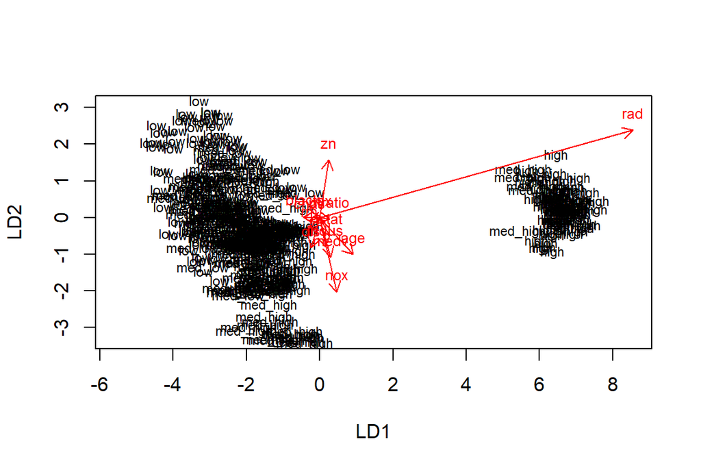

```r
lda.arrows <- function(x, myscale = 1, arrow_heads = 0.1, color = "red", tex = 0.75, choices = c(1,2)){
  heads <- coef(x)
  graphics::arrows(x0 = 0, y0 = 0,
         x1 = myscale * heads[,choices[1]],
         y1 = myscale * heads[,choices[2]], col=color, length = arrow_heads)
  text(myscale * heads[,choices], labels = row.names(heads),
       cex = tex, col=color, pos=3)
}

# Classes to numerical values
classes <- as.numeric(train$crime)

# Drawing LDA biplot
plot(lda.fit, dimen = 2)
lda.arrows(lda.fit, myscale = 2.5)
```

It’s kinda hard to interpret the plot. There might be a another solution as well. Let’s try that.

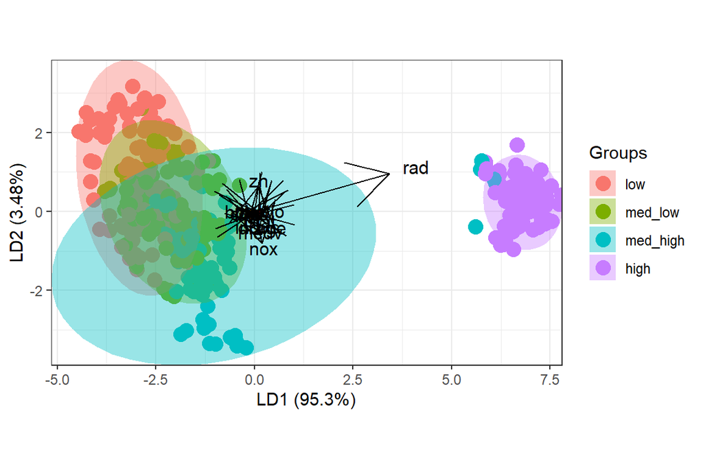

```r
suppressWarnings({
library(devtools)
library(ggord)
  })
ggord(lda.fit, train$crime, arrow = 1)
```

At least from the latter the groups are easier to see.

## 6 Test set, predictions

### Test set

```r
# Test set out of Boston_scaled
test <-Boston_scaled[-ind,]

# Correct classes that will be removed from the test data
test_correct_classes <- as.data.frame(test$crime)
# Removing the correct classes
test <- dplyr::select(test, -crime)
```

### Predicting

```r
# Predict classes with test data (20%) of the whole data
lda.pred <- predict(lda.fit, newdata = test)

# I had trouble of getting the table function to work, it helped to convert the data frames into vectors that is below
test_pred_classes <- as.data.frame(lda.pred$class)

test_correct_classes_v <- unlist(test_correct_classes)
test_pred_classes_v <- unlist(test_pred_classes)

# Cross tabulating the results on crime rate
table(correct = test_correct_classes_v, predicted = test_pred_classes_v)
```

```
##           predicted
## correct    low med_low med_high high
##   low       14       4        1    0
##   med_low    6      13        3    0
##   med_high   0       9       17    1
##   high       0       0        1   33
```

Cross tabulation of the crime rate predicted values using LDA vs. the correct values from the test data (extracted earlier).

76% success rate is okay, but not good I would say. The training data is small as is the test data, so better accuracy would be achieved using larger data sets. At least that’s my hypothesis.

## 7 K-means Clustering

```r
# Boston data already loaded, standardization again as the Boston_scaled has been modified

Boston_scaled2 <- as.data.frame(scale(Boston))
Boston_scaled2$crim <- as.numeric(Boston_scaled2$crim)

# Euclidean distance matrix
dist_eu <- dist(Boston_scaled2, method = "euclidean")
summary(dist_eu)
```

```
##    Min. 1st Qu.  Median    Mean 3rd Qu.    Max.
##  0.1343  3.4625  4.8241  4.9111  6.1863 14.3970
```

```r
# Manhattan distance matrix
dist_man <- dist(Boston_scaled2, method = "manhattan")
summary(dist_man)
```

```
##    Min. 1st Qu.  Median    Mean 3rd Qu.    Max.
##  0.2662  8.4832 12.6090 13.5488 17.7568 48.8618
```

```r
set.seed(13)
```

### K-means clustering with 4 cluster centers

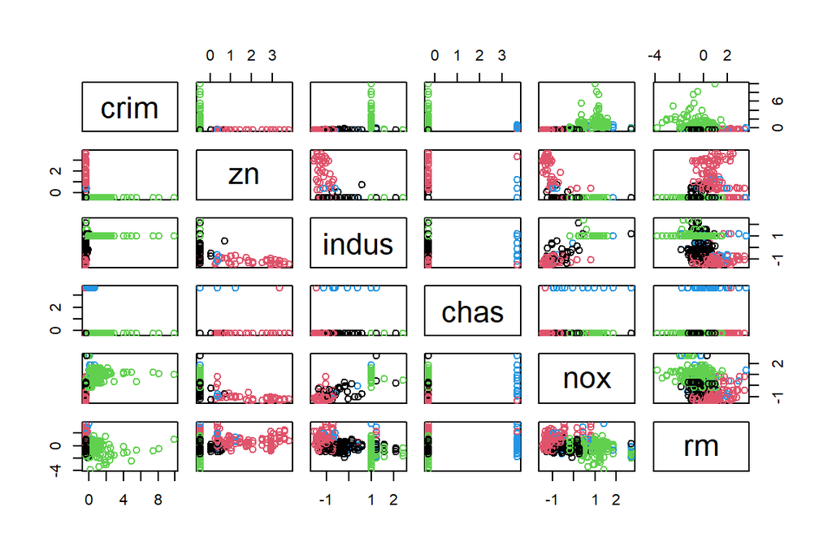

```r
# k-means clustering
km <- kmeans(Boston_scaled2, centers = 4)

pairs(Boston_scaled2[1:6], col = km$cluster)
```

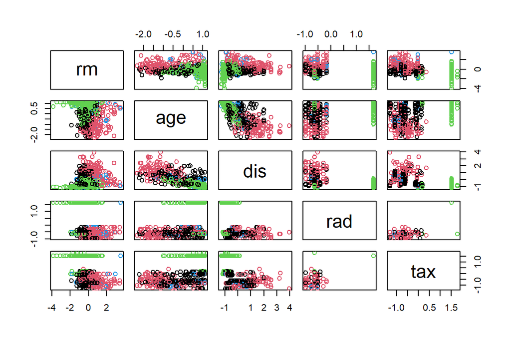

```r
pairs(Boston_scaled2[6:10], col = km$cluster)
```

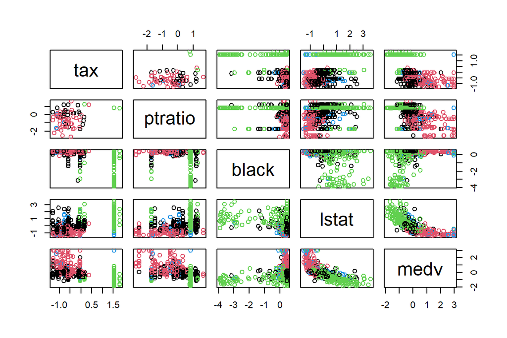

```r
pairs(Boston_scaled2[10:14], col = km$cluster)
```

### K-means clustering with 3 cluster centers

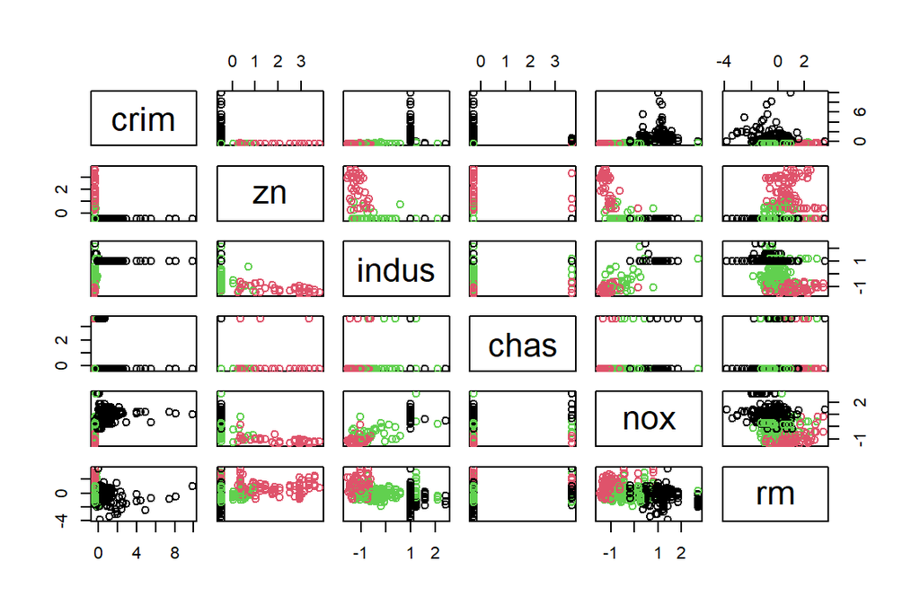

```r
km <- kmeans(Boston_scaled2, centers = 3)

pairs(Boston_scaled2[1:6], col = km$cluster)
```

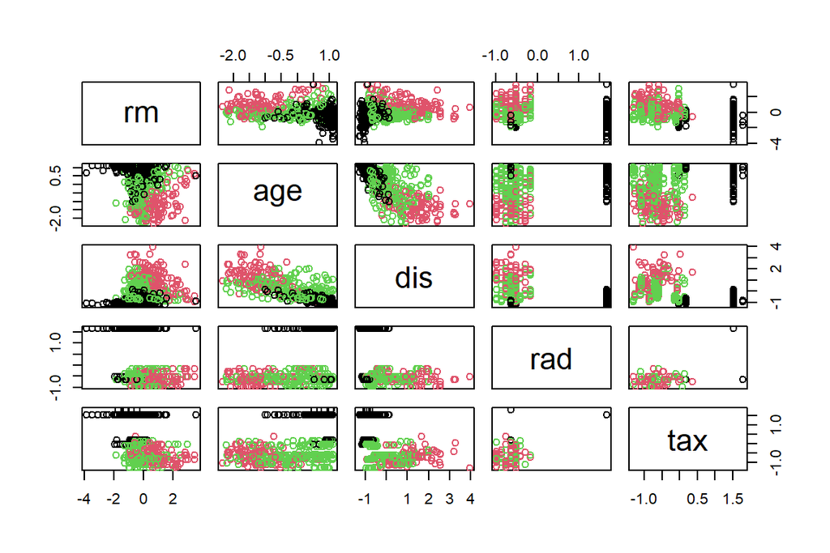

```r
pairs(Boston_scaled2[6:10], col = km$cluster)
```

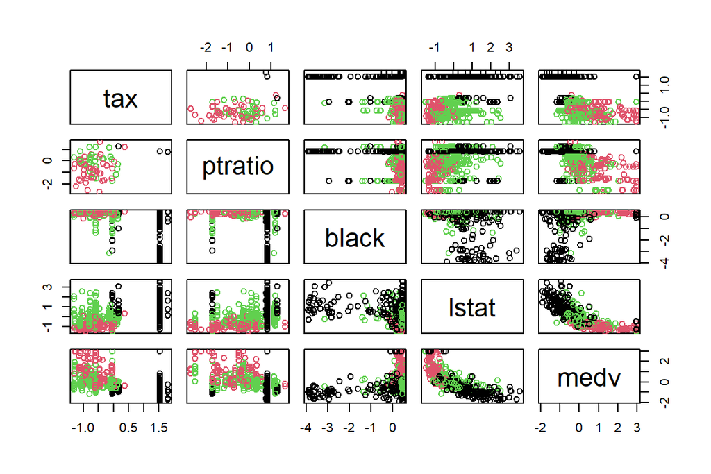

```r
pairs(Boston_scaled2[10:14], col = km$cluster)
```

I think it’s quite difficult to see from these plots what would be the optimal number of clusters. So, let’s move to the next step to determine the optimal value using total of wihin cluster sum of squares (TWCS).